# Практикум 1. Модели с переменными взаимодействия

Скачаем и подключим библиотеки

```r
library(haven)
library(dplyr)
library(ggplot2)
library(margins)
library(psych)
library(memisc)
```

**Задание 1.** Постройте модель регрессии (1), в которой откликом выступает эффективность государственного управления (wbge), предикторами – уровень демократии (fhpolity), логарифм ВВП на душу населения (lngdppc), переменная взаимодействия между уровнем демократии и логарифмом ВВП на душу населения. Проинтерпретируйте оценки коэффициентов при всех предикторах.

Построим модель и проинтерпретируем коэффициенты

```r
data <- read_dta("tvims3_lab1_2.dta")
head(data)
```

```
## # A tibble: 6 x 5
##   cname      dembinary fhpolity   wbge lngdppc
##   <chr>          <dbl>    <dbl>  <dbl>   <dbl>
## 1 Albania            1     7.58 -0.569    8.33
## 2 Algeria            0     3    -0.615    8.65
## 3 Angola             0     3.25 -1.25     7.59
## 4 Azerbaijan         0     2    -0.948    8.26
## 5 Argentina          1     7.83 -0.260    9.17
## 6 Australia          1    10     1.70    10.2
```

```r
model1 <- lm(wbge ~ fhpolity + lngdppc + lngdppc:fhpolity, data = data)
summary(model1)
```

```
##
## Call:
## lm(formula = wbge ~ fhpolity + lngdppc + lngdppc:fhpolity, data = data)
##
## Residuals:
##      Min       1Q   Median       3Q      Max
## -1.25511 -0.29618 -0.04548  0.35566  1.83784
##
## Coefficients:
##                  Estimate Std. Error t value Pr(>|t|)
## (Intercept)      -2.32032    0.63434  -3.658  0.00035 ***
## fhpolity         -0.42174    0.10340  -4.079 7.29e-05 ***
## lngdppc           0.18247    0.07586   2.405  0.01736 *
## fhpolity:lngdppc  0.06088    0.01164   5.229 5.55e-07 ***
## ---
## Signif. codes:  0 '***' 0.001 '**' 0.01 '*' 0.05 '.' 0.1 ' ' 1
##
## Residual standard error: 0.4987 on 152 degrees of freedom
## Multiple R-squared:  0.7566, Adjusted R-squared:  0.7518
## F-statistic: 157.5 on 3 and 152 DF,  p-value: < 2.2e-16
```

Константа: Среднее значение эффективности государственного управления в странах будет равно -2.32032 при условии того, что логарифм от ВВП на душу населения и уровень демократии равны 0, как и переменная взаимодействия

fhpolity: При изменении демократичности режима на 1 при условии, что логарифм от ВВП на душу населения =0, в среднем значение эффективности государственного управления будет уменьшаться на 0.42174

lngdppc: При изменении логарифма от уровня ВВП на душу на 1 в странах, где уровень демократичности по fhpolity оценен как = 0,в среднем значение эффективности государственного управления будет в среднем увеличиваться на 0.18247

Переменная взаимодействия lngdppc:fhpolity: При изменении демократичности режима на 1 взаимосвязь логарифма от ВВП на душу населения и эффективности государственного управления становится более выраженной положительной: коэффициент взаимосвязи в среднем увеличивается на 0.06088. (возможна зеркальная интерпретация)

**Задание 2.** Преобразуйте шкалу переменной логарифма ВВП на душу населения так, чтобы она включала значение 0. Оцените модель регрессии (2) с преобразованной переменной, при этом сохраните такую же спецификацию, как и в предыдущей модели. Интерпретация оценок каких коэффициентов изменится по сравнению с соответствующими оценками коэффициентов в модели (1)? Приведите новую интерпретацию.

```r
data1 <- data
data1 <- na.omit(data1)
data1$lngdppc_new = data1$lngdppc - mean(data1$lngdppc)
describe(data1$lngdppc_new)
```

```
##    vars   n mean   sd median trimmed  mad   min  max range  skew kurtosis   se
## X1    1 156    0 1.18   0.02    0.02 1.37 -2.63 1.99  4.62 -0.13    -1.04 0.09
```

Мы центрировали данные так, чтобы шкала переменной логарифма ВВП на душу населения включала значение 0, заново построим модель

```r
model2 <- lm(wbge ~ fhpolity + lngdppc_new + lngdppc_new:fhpolity, data = data1)
summary(model2)
```

```
##
## Call:
## lm(formula = wbge ~ fhpolity + lngdppc_new + lngdppc_new:fhpolity,
##     data = data1)
##
## Residuals:
##      Min       1Q   Median       3Q      Max
## -1.25511 -0.29618 -0.04548  0.35566  1.83784
##
## Coefficients:
##                      Estimate Std. Error t value Pr(>|t|)
## (Intercept)          -0.77854    0.09566  -8.138 1.33e-13 ***
## fhpolity              0.09270    0.01471   6.302 3.03e-09 ***
## lngdppc_new           0.18247    0.07586   2.405   0.0174 *
## fhpolity:lngdppc_new  0.06088    0.01164   5.229 5.55e-07 ***
## ---
## Signif. codes:  0 '***' 0.001 '**' 0.01 '*' 0.05 '.' 0.1 ' ' 1
##
## Residual standard error: 0.4987 on 152 degrees of freedom
## Multiple R-squared:  0.7566, Adjusted R-squared:  0.7518
## F-statistic: 157.5 on 3 and 152 DF,  p-value: < 2.2e-16
```

Константа: Среднее значение эффективности государственного управления в странах будет равно -0.77854 при условии того, что центрированный логарифм от ВВП на душу населения и уровень демократии равны 0, как и переменная взаимодействия

fhpolity: При изменении демократичности режима на 1 в странах, где логарифм от ВВП на душу населения =0, в среднем значение эффективности государственного управления будет увеличиваться на 0.09270

lngdppc: При изменении логарифма от уровня ВВП на душу на 1 в странах, где уровень демократичности по fhpolity оценен как = 0,в среднем значение эффективности государственного управления будет увеличиваться на 0.18247

Переменная взаимодействия lngdppc:fhpolity: При изменении демократичности режима на 1 взаимосвязь логарифма от ВВП на душу населения и эффективности государственного управления становится более выраженной положительной: коэффициент взаимосвязи в среднем увеличивается на 0.06088. (возможна зеркальная интерпретация)

**Задание 3.** Рассчитайте предельные эффекты изменения логарифма ВВП на душу населения на эффективность государственного управления при разных значениях уровня демократии (fhpolity).

Cредние значения предельных эффектов

```r
margins_model1 <- margins(model2)
summary(margins_model1)
```

```
##       factor    AME     SE       z      p  lower  upper
##     fhpolity 0.0927 0.0147  6.3017 0.0000 0.0639 0.1215
##  lngdppc_new 0.5559 0.0381 14.6048 0.0000 0.4813 0.6305
```

Полученные предельные эффекта являются значимыми(т.к. Pvalue невелико + доверительные интервалы не накрывают 0)

Значения предельных эффектов при разных значениях уровня демократии

```r
margins_model2 <- margins(model2, at = list(fhpolity = 0:10))
summary(margins_model2)
```

```
##       factor fhpolity    AME     SE       z      p  lower  upper
##     fhpolity   0.0000 0.0927 0.0147  6.3018 0.0000 0.0639 0.1215
##     fhpolity   1.0000 0.0927 0.0147  6.3017 0.0000 0.0639 0.1215
##     fhpolity   2.0000 0.0927 0.0147  6.3017 0.0000 0.0639 0.1215
##     fhpolity   3.0000 0.0927 0.0147  6.3018 0.0000 0.0639 0.1215
##     fhpolity   4.0000 0.0927 0.0147  6.3017 0.0000 0.0639 0.1215
##     fhpolity   5.0000 0.0927 0.0147  6.3017 0.0000 0.0639 0.1215
##     fhpolity   6.0000 0.0927 0.0147  6.3017 0.0000 0.0639 0.1215
##     fhpolity   7.0000 0.0927 0.0147  6.3017 0.0000 0.0639 0.1215
##     fhpolity   8.0000 0.0927 0.0147  6.3017 0.0000 0.0639 0.1215
##     fhpolity   9.0000 0.0927 0.0147  6.3017 0.0000 0.0639 0.1215
##     fhpolity  10.0000 0.0927 0.0147  6.3017 0.0000 0.0639 0.1215
##  lngdppc_new   0.0000 0.1825 0.0759  2.4053 0.0162 0.0338 0.3311
##  lngdppc_new   1.0000 0.2434 0.0660  3.6869 0.0002 0.1140 0.3727
##  lngdppc_new   2.0000 0.3042 0.0568  5.3533 0.0000 0.1928 0.4156
##  lngdppc_new   3.0000 0.3651 0.0487  7.4935 0.0000 0.2696 0.4606
##  lngdppc_new   4.0000 0.4260 0.0423 10.0703 0.0000 0.3431 0.5089
##  lngdppc_new   5.0000 0.4869 0.0384 12.6727 0.0000 0.4116 0.5622
##  lngdppc_new   6.0000 0.5478 0.0379 14.4661 0.0000 0.4736 0.6220
##  lngdppc_new   7.0000 0.6087 0.0408 14.9269 0.0000 0.5287 0.6886
##  lngdppc_new   8.0000 0.6695 0.0465 14.3974 0.0000 0.5784 0.7607
##  lngdppc_new   9.0000 0.7304 0.0542 13.4854 0.0000 0.6243 0.8366
##  lngdppc_new  10.0000 0.7913 0.0631 12.5494 0.0000 0.6677 0.9149
```

**1.**Проинтерпретируйте результаты, в частности, укажите, как изменяется предельный эффект с ростом уровня демократии на единицу шкалы измерения.

Логарифм ВВП на душу населения оказывает положительный эффект на зависимую переменную. При увеличении уровня демократии на 1 в среднем значение предельного эффекта будет увеличиваться в соответствие с данными из второй таблицы (пересечение строчек lngdppc и столбца AME).

**2.**Постройте график, демонстрирующий изменение предельного эффекта в зависимости от уровня демократии (по оси абсцисс – уровень демократии). Проинтерпретируйте данный график.

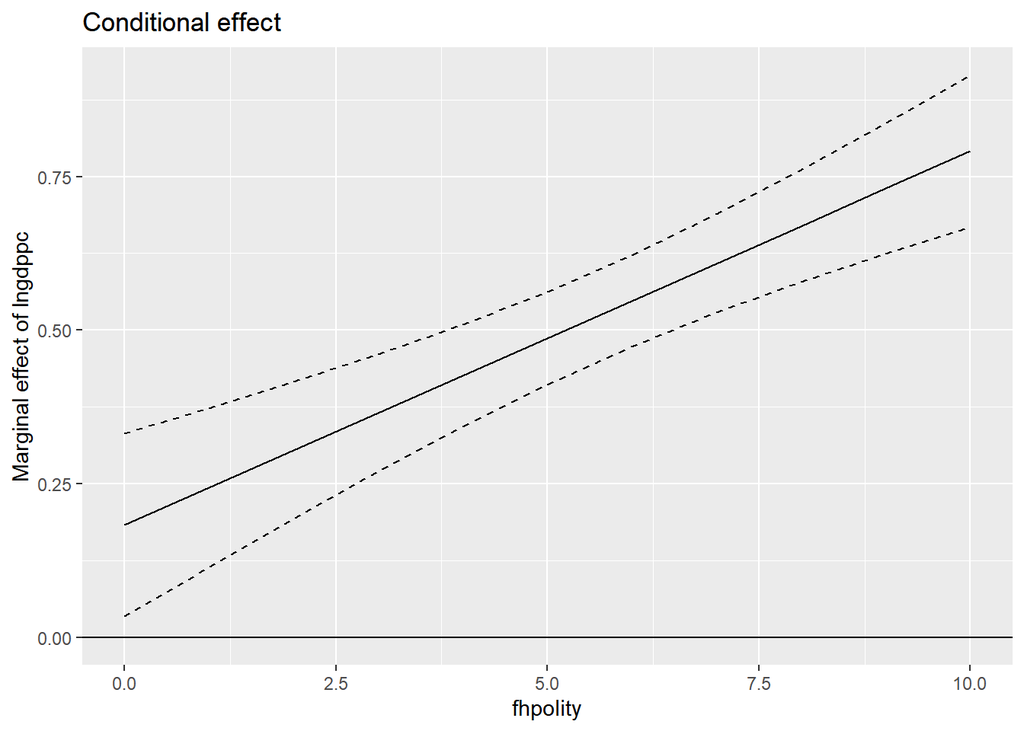

```r
ggplot(margins_model2, aes(x = fhpolity)) +
  geom_line(aes(y = dydx_lngdppc_new)) +
  geom_line(aes(y = dydx_lngdppc_new+1.96*sqrt(Var_dydx_lngdppc_new)), linetype = 2) +
  geom_line(aes(y = dydx_lngdppc_new-1.96*sqrt(Var_dydx_lngdppc_new)), linetype = 2) +
  geom_hline(yintercept = 0) +
  ggtitle("Conditional effect") +
  xlab("fhpolity") + ylab("Marginal effect of lngdppc")
```

График повторяет ранее данный нами вывод - при увеличении уровня демократии предельный эффект ВВПНД на зависимую переменную увеличивается, при этом доверительные интервалы не захватывают 0, т.е. он значим.

**Задание 4.** Оцените модель регрессии (3), в которой откликом выступает эффективность государственного управления (wbge), предикторами – индикатор политического режима, представленный в бинарной шкале (dembinary), логарифм ВВП на душу населения (lngdppc), переменная взаимодействия между политическим режимом (dembinary) и логарифмом ВВП на душу населения.

```r
model3 <- lm(wbge ~ dembinary + lngdppc_new + dembinary:lngdppc_new, data=data1)
summary(model3)
```

```
##
## Call:
## lm(formula = wbge ~ dembinary + lngdppc_new + dembinary:lngdppc_new,
##     data = data1)
##
## Residuals:
##      Min       1Q   Median       3Q      Max
## -1.31992 -0.32893 -0.06789  0.39231  1.80160
##
## Coefficients:
##                       Estimate Std. Error t value Pr(>|t|)
## (Intercept)           -0.42193    0.07105  -5.939 1.88e-08 ***
## dembinary              0.41609    0.09487   4.386 2.15e-05 ***
## lngdppc_new            0.37826    0.05878   6.436 1.52e-09 ***
## dembinary:lngdppc_new  0.42344    0.08008   5.288 4.24e-07 ***
## ---
## Signif. codes:  0 '***' 0.001 '**' 0.01 '*' 0.05 '.' 0.1 ' ' 1
##
## Residual standard error: 0.5557 on 152 degrees of freedom
## Multiple R-squared:  0.6977, Adjusted R-squared:  0.6917
## F-statistic: 116.9 on 3 and 152 DF,  p-value: < 2.2e-16
```

Рассчитайте и проинтерпретируйте предсказанные значения эффективности государственного управления при максимальном значении логарифма ВВП на душу населения в демократических и недемократических политических режимах.

х учитывает демократические режимы у - не учитывает

```r
x=-0.42193+0.41609+0.37826*1.99+0.42344*1.99
x
```

```
## [1] 1.589543
```

```r
y=-0.42193+0.37826*1.99
y
```

```
## [1] 0.3308074
```

**Задание 5.** Чему равны оценки констант и коэффициента при предикторе «логарифм ВВП на душу населения» в моделях, оцененных на отдельных выборках (такие выборки сформированы на основании значения показателя dembinary)? Зависимой переменной остается эффективность государственного управления. Покажите, как можно получить эти оценки коэффициентов из оценок модели (3).

```r
interactions1 <- subset(data1, dembinary == 1)
model3_1 <- lm(wbge ~ lngdppc_new, data = interactions1)
summary(model3_1)
```

```
##
## Call:
## lm(formula = wbge ~ lngdppc_new, data = interactions1)
##
## Residuals:
##      Min       1Q   Median       3Q      Max
## -1.29789 -0.30594 -0.04225  0.38085  1.02732
##
## Coefficients:
##              Estimate Std. Error t value Pr(>|t|)
## (Intercept) -0.005838   0.056718  -0.103    0.918
## lngdppc_new  0.801702   0.049073  16.337   <2e-16 ***
## ---
## Signif. codes:  0 '***' 0.001 '**' 0.01 '*' 0.05 '.' 0.1 ' ' 1
##
## Residual standard error: 0.5014 on 84 degrees of freedom
## Multiple R-squared:  0.7606, Adjusted R-squared:  0.7578
## F-statistic: 266.9 on 1 and 84 DF,  p-value: < 2.2e-16
```

```r
interactions0 <- subset(data1, dembinary == 0)
model3_2 <- lm(wbge ~ lngdppc_new, data = interactions0)
summary(model3_2)
```

```
##
## Call:
## lm(formula = wbge ~ lngdppc_new, data = interactions0)
##
## Residuals:
##     Min      1Q  Median      3Q     Max
## -1.3199 -0.3390 -0.1145  0.3866  1.8016
##
## Coefficients:
##             Estimate Std. Error t value Pr(>|t|)
## (Intercept) -0.42193    0.07879  -5.355 1.09e-06 ***
## lngdppc_new  0.37826    0.06518   5.803 1.87e-07 ***
## ---
## Signif. codes:  0 '***' 0.001 '**' 0.01 '*' 0.05 '.' 0.1 ' ' 1
##
## Residual standard error: 0.6163 on 68 degrees of freedom
## Multiple R-squared:  0.3312, Adjusted R-squared:  0.3214
## F-statistic: 33.68 on 1 and 68 DF,  p-value: 1.87e-07
```

```r
mtable(model3, model3_1, model3_2)
```

```
##
## Calls:
## model3: lm(formula = wbge ~ dembinary + lngdppc_new + dembinary:lngdppc_new,
##     data = data1)
## model3_1: lm(formula = wbge ~ lngdppc_new, data = interactions1)
## model3_2: lm(formula = wbge ~ lngdppc_new, data = interactions0)
##
## =============================================================
##                              model3    model3_1   model3_2
## -------------------------------------------------------------
##   (Intercept)               -0.422***  -0.006     -0.422***
##                             (0.071)    (0.057)    (0.079)
##   dembinary                  0.416***
##                             (0.095)
##   lngdppc_new                0.378***   0.802***   0.378***
##                             (0.059)    (0.049)    (0.065)
##   dembinary x lngdppc_new    0.423***
##                             (0.080)
## -------------------------------------------------------------
##   R-squared                  0.698      0.761      0.331
##   N                        156         86         70
## =============================================================
##   Significance: *** = p < 0.001; ** = p < 0.01;
##                 * = p < 0.05
```

В модели, учитывающей только значения демократий(model3_1), значение константы =-0.006, а значение коэффициента при предикторе lngdppc_new=0.802. В модели, учитывающей только значения НЕ-демократий(model3_2), значение константы =-0.422, а значение коэффициента при предикторе lngdppc_new=0.378

Оценку константы модели, учитывающей только значения демократий, можно получить, если мы прибавим значение бинарной переменной dembinary к константе модели model3 Оценку переменной lngdppc_new модели, учитывающей только значения демократий, можно получить, если мы прибавим значение переменной взаимодействия к значению переменной lngdppc_new в модели model3